# 7-new_index

A new index has been created in `interesting-indices.r` to compare the similarity between the projected distribution and a standard normal distribution. Since the data has been centered to zero mean and scaled to variance = 1, it is valid to compare the distribution with a *standard* normal. Setting the number of bins to be 10 (This is a tuning parameter and we keep it as 10 for now), the number of points falling in each bin is counted in both distributions (`mat_bin_count`, `norm_bin_count`). The output statistic is the sum of squared difference over number of points: `diff <- sum((mat_bin_count - norm_bin_count)^2)/nrow(mat)` where `mat` is the projected data. Currently, the index is computed for 1-D projection, computation for 2D index is possible with 2D binning available with `ash::bin2()` in `ash` package.

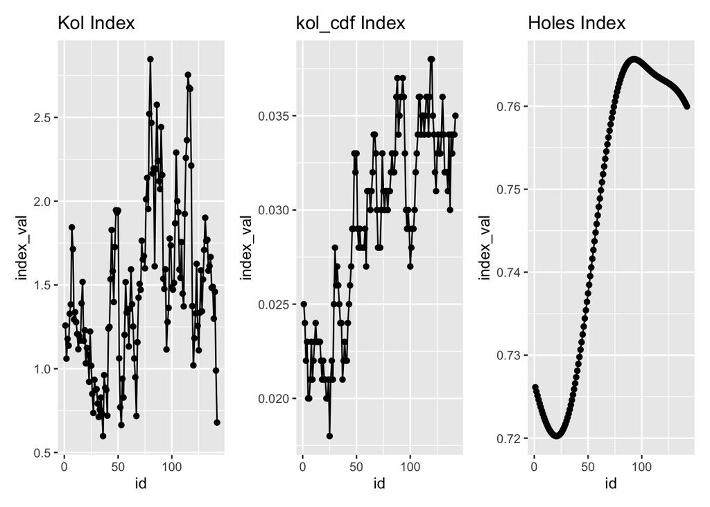

```r
noise <- data %>% dplyr::select(-x2)

set.seed(123456)
d <- 1
basis1 <- tourr::basis_random(ncol(data), d)
basis2 <- tourr::basis_random(ncol(data), d)

basis1 <- matrix(c(1,rep(0, 3)))
basis2 <- matrix(c(rep(0, 3), 1))
geo <- tourr::geodesic_path(basis1, basis2)


cur_dist <- 0
target_dist <- geo$dist
pos <- seq(cur_dist, target_dist, 1/100)
interp <- tourr:::geodesic_info(basis1, basis2)

# path_kol <- tibble(index_val = map_dbl(pos,
#                                    ~tourr:::step_fraction(interp = interp, fraction = .x) %>%
#                                      calc_kol(data = data))) %>% mutate(id = row_number())
#
# path_kol_cdf <- tibble(index_val = map_dbl(pos,
#                                    ~tourr:::step_fraction(interp = interp, fraction = .x) %>%
#                                      calc_kol_cdf(data = data))) %>% mutate(id = row_number())
#
# path_holes <- tibble(index_val = map_dbl(pos,
#                                    ~tourr:::step_fraction(interp = interp, fraction = .x) %>%
#                                      calc_index(data = data))) %>% mutate(id = row_number())

path_kol <- tibble(index_val = map_dbl(pos,
                                   ~tourr:::step_fraction(interp = interp, fraction = .x) %>%
                                     calc_kol(data = noise))) %>% mutate(id = row_number())

path_kol_cdf <- tibble(index_val = map_dbl(pos,
                                   ~tourr:::step_fraction(interp = interp, fraction = .x) %>%
                                     calc_kol_cdf(data = noise))) %>% mutate(id = row_number())

path_holes <- tibble(index_val = map_dbl(pos,
                                   ~tourr:::step_fraction(interp = interp, fraction = .x) %>%
                                     calc_index(data = noise))) %>% mutate(id = row_number())

p1 <- path_kol %>% ggplot(aes(x = id, y = index_val)) +
  geom_line() +
  geom_point() +
  ggtitle("Kol Index")

p2 <- path_kol_cdf %>% ggplot(aes(x = id, y = index_val)) +
  geom_line() +
  geom_point() +
  ggtitle("kol_cdf Index")

p3 <- path_holes %>% ggplot(aes(x = id, y = index_val)) +
  geom_line() +
  geom_point() +
  ggtitle("Holes Index")

p1 | p2 | p3
```